# 5622-final-project-cub

### 1. Project Topic and Goal

**Topic**: Predicting the Onset of Diabetes in Patients

**Goal**: The goal of this project is to build and evaluate supervised machine learning models to predict whether a patient has diabetes based on diagnostic measurements. The models will be trained on a dataset of medical records to provide insights into which features are most indicative of diabetes and to develop a predictive tool for early diagnosis.

### 2. Data Description

**Source**: The dataset is the "Pima Indians Diabetes Database," available from the UCI Machine Learning Repository. It consists of diagnostic measurements for 768 female patients of Pima Indian heritage, aged 21 and older.

**Features**:

- `Pregnancies`: Number of times the patient has been pregnant.
- `Glucose`: Plasma glucose concentration after 2 hours in an oral glucose tolerance test.
- `BloodPressure`: Diastolic blood pressure (mm Hg).
- `SkinThickness`: Triceps skinfold thickness (mm).
- `Insulin`: 2-Hour serum insulin (mu U/ml).
- `BMI`: Body mass index (weight in kg/(height in m)^2).
- `DiabetesPedigreeFunction`: A function that represents a patient's likelihood of having diabetes based on family history.
- `Age`: Patient's age (years).
- `Outcome`: Binary outcome variable (1 indicates the presence of diabetes, 0 indicates absence).

### 3. Data Import

```python
import pandas as pd

# Load the dataset
data = pd.read_csv('data/diabetes.csv')

# Display the first few rows of the dataset
data.head()
```

|  | Pregnancies | Glucose | BloodPressure | SkinThickness | Insulin | BMI | DiabetesPedigreeFunction | Age | Outcome |
| --- | --- | --- | --- | --- | --- | --- | --- | --- | --- |
| 0 | 6 | 148 | 72 | 35 | 0 | 33.6 | 0.627 | 50 | 1 |
| 1 | 1 | 85 | 66 | 29 | 0 | 26.6 | 0.351 | 31 | 0 |
| 2 | 8 | 183 | 64 | 0 | 0 | 23.3 | 0.672 | 32 | 1 |
| 3 | 1 | 89 | 66 | 23 | 94 | 28.1 | 0.167 | 21 | 0 |
| 4 | 0 | 137 | 40 | 35 | 168 | 43.1 | 2.288 | 33 | 1 |

### 4. Data Cleaning

**Introduction**: The dataset will be cleaned by handling missing values, removing duplicates, and ensuring the data types are appropriate.

```python
# Check for missing values across the dataset
missing_values = data.isnull().sum()
print("\nMissing values in each column:")
print(missing_values)

# Check for duplicate rows
duplicates = data.duplicated().sum()
print(f"\nNumber of duplicate rows in the dataset: {duplicates}")

# Drop duplicates if they exist
if duplicates > 0:
    data_cleaned = data.drop_duplicates()
    print(f"Number of rows after removing duplicates: {data_cleaned.shape[0]}")
else:
    data_cleaned = data.copy()  # No duplicates, proceed with the original data

# Summary of Data Cleaning:
# - No missing values were found in the dataset.
# - No duplicate rows were found.
# - Data types are appropriate for each column.

# Display the cleaned dataset's basic statistics to confirm that it's ready for analysis
print("\nSummary statistics of the cleaned dataset:")
print(data_cleaned.describe())
```

```
Missing values in each column:
Pregnancies                 0
Glucose                     0
BloodPressure               0
SkinThickness               0
Insulin                     0
BMI                         0
DiabetesPedigreeFunction    0
Age                         0
Outcome                     0
dtype: int64

Number of duplicate rows in the dataset: 0

Summary statistics of the cleaned dataset:
       Pregnancies     Glucose  BloodPressure  SkinThickness     Insulin  \
count   768.000000  768.000000     768.000000     768.000000  768.000000
mean      3.845052  120.894531      69.105469      20.536458   79.799479
std       3.369578   31.972618      19.355807      15.952218  115.244002
min       0.000000    0.000000       0.000000       0.000000    0.000000
25%       1.000000   99.000000      62.000000       0.000000    0.000000
50%       3.000000  117.000000      72.000000      23.000000   30.500000
75%       6.000000  140.250000      80.000000      32.000000  127.250000
max      17.000000  199.000000     122.000000      99.000000  846.000000

              BMI  DiabetesPedigreeFunction         Age     Outcome
count  768.000000                768.000000  768.000000  768.000000
mean    31.992578                  0.471876   33.240885    0.348958
std      7.884160                  0.331329   11.760232    0.476951
min      0.000000                  0.078000   21.000000    0.000000
25%     27.300000                  0.243750   24.000000    0.000000
50%     32.000000                  0.372500   29.000000    0.000000
75%     36.600000                  0.626250   41.000000    1.000000
max     67.100000                  2.420000   81.000000    1.000000
```

## 5. Exploratory Data Analysis (EDA)

**Introduction**: We will perform EDA to understand the distribution of features and the relationships between them.

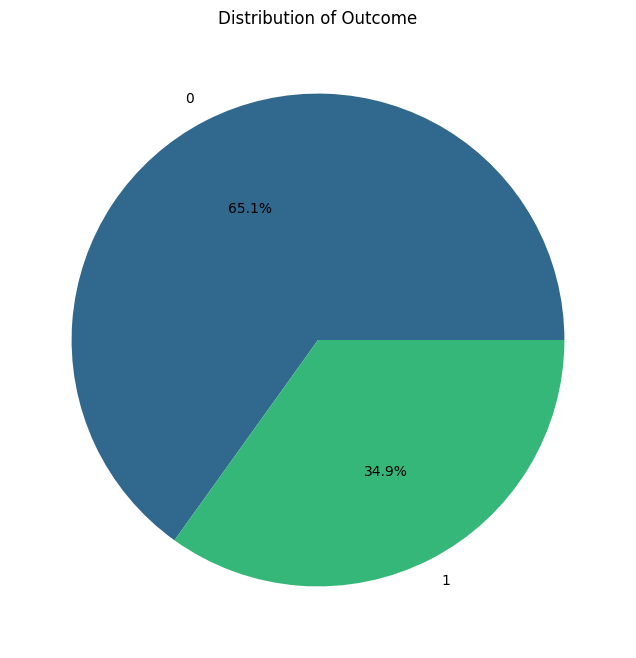

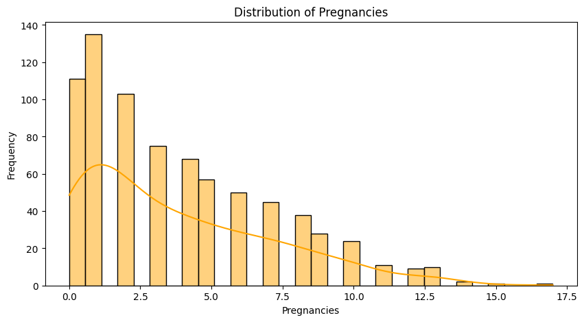

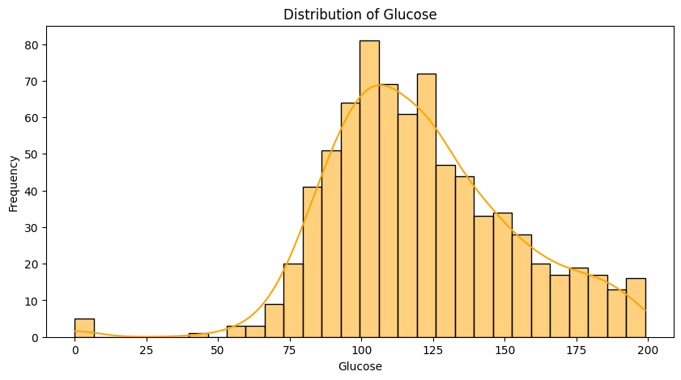

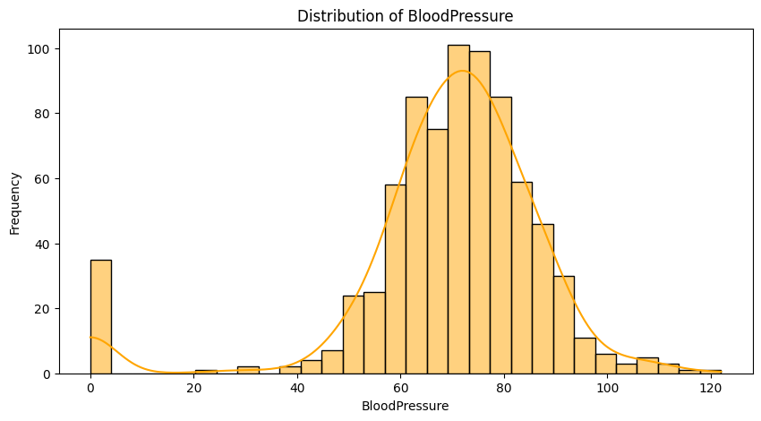

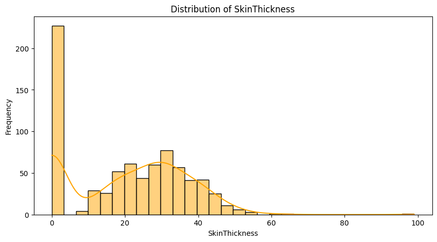

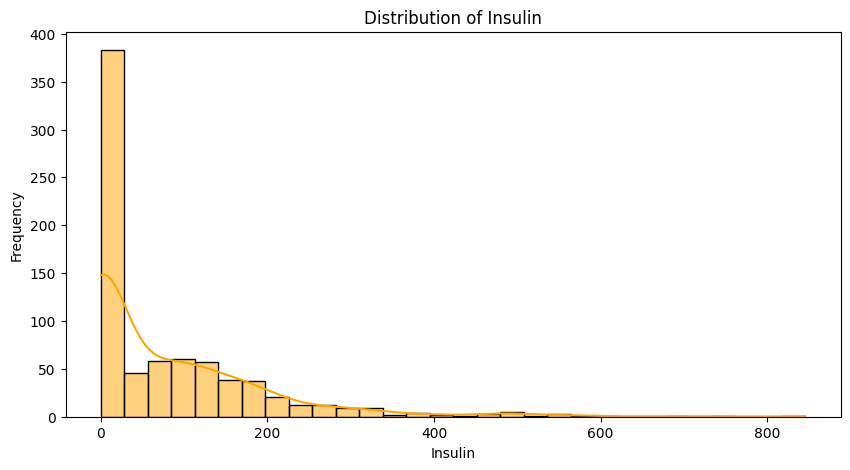

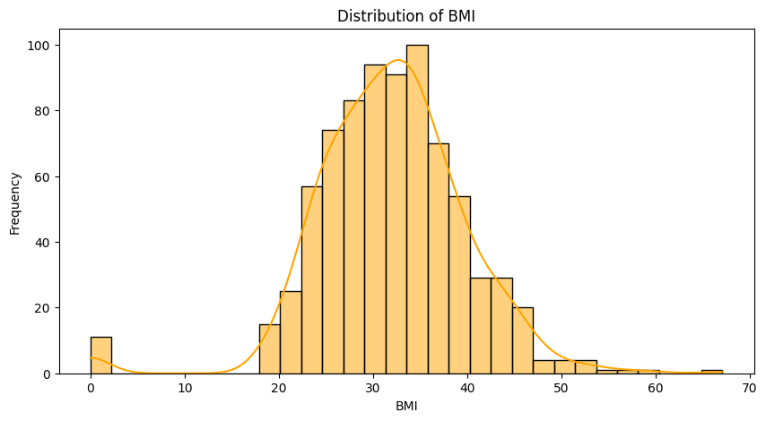

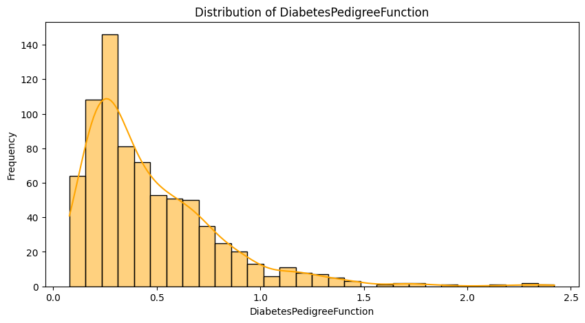

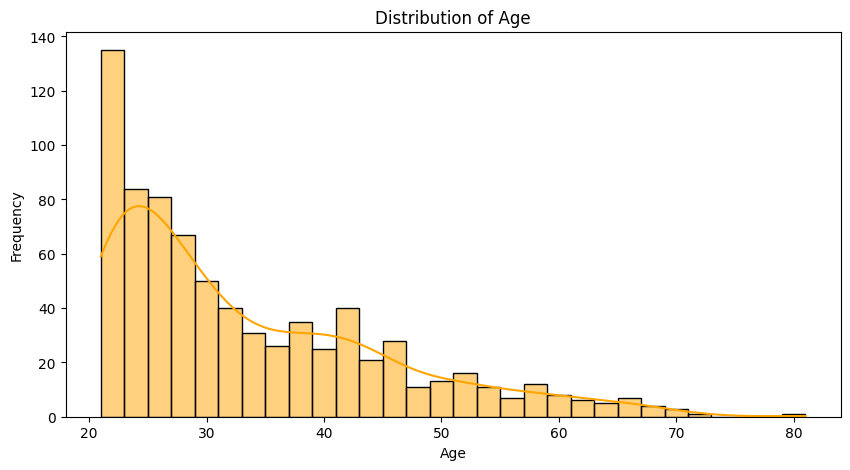

```python
import matplotlib.pyplot as plt
import seaborn as sns

# Set up the figure size for the plots
plt.figure(figsize=(8, 8))

# Plot the distribution of the target variable 'Outcome' as a pie chart
outcome_counts = data_cleaned['Outcome'].value_counts()
plt.pie(outcome_counts, labels=outcome_counts.index, autopct='%1.1f%%', colors=sns.color_palette('viridis', len(outcome_counts)))
plt.title('Distribution of Outcome')
plt.show()

# Display the distribution of every feature
for column in data_cleaned.columns[:-1]:  # Exclude the 'Outcome' column
    plt.figure(figsize=(10, 5))
    sns.histplot(data_cleaned[column], kde=True, color='orange', bins=30)
    plt.title(f'Distribution of {column}')
    plt.xlabel(column)
    plt.ylabel('Frequency')
    plt.show()

# Generate summary statistics
summary_stats = data_cleaned.describe()
```